# XCL1

## Figure 6: Deep-MSA contact map panel / Best clusters contact map panel

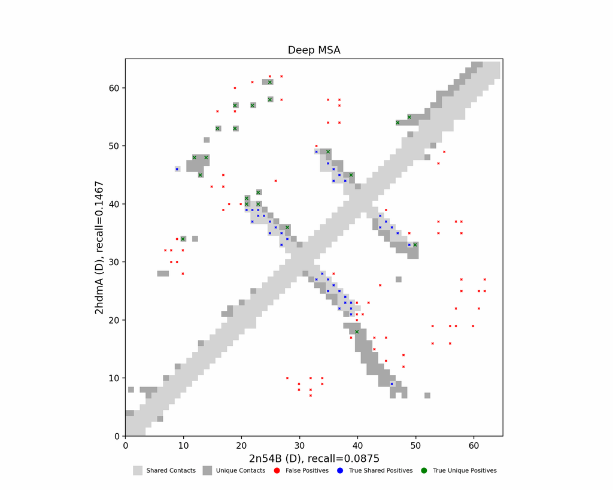

Deep-MSA contact map panel

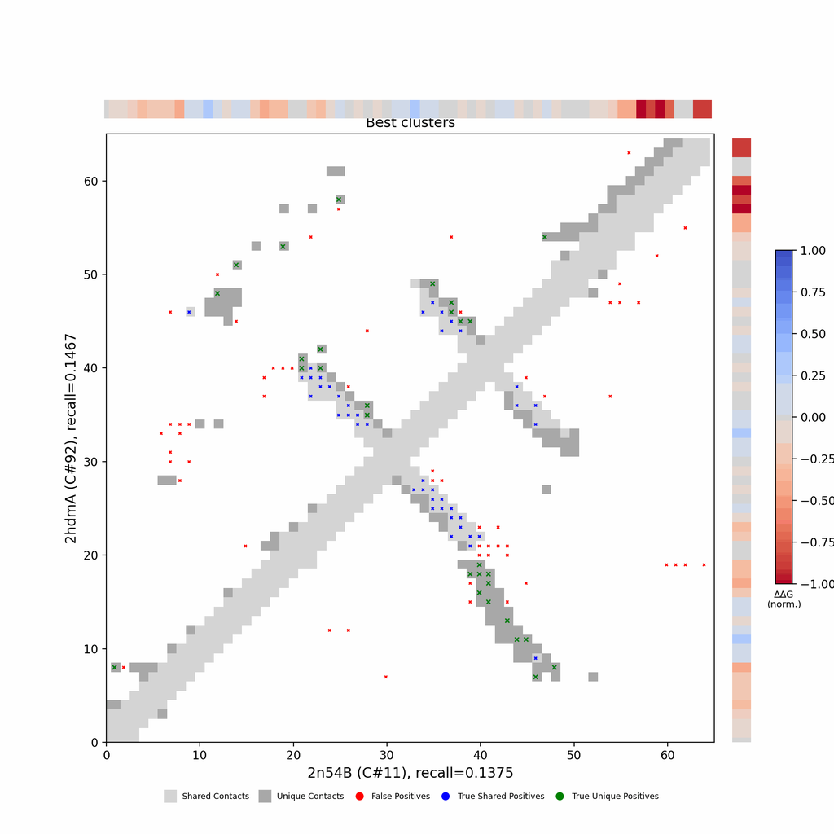

Best clusters contact map panel

## Figure 7: All clusters contact-map mosaic (small multiples).

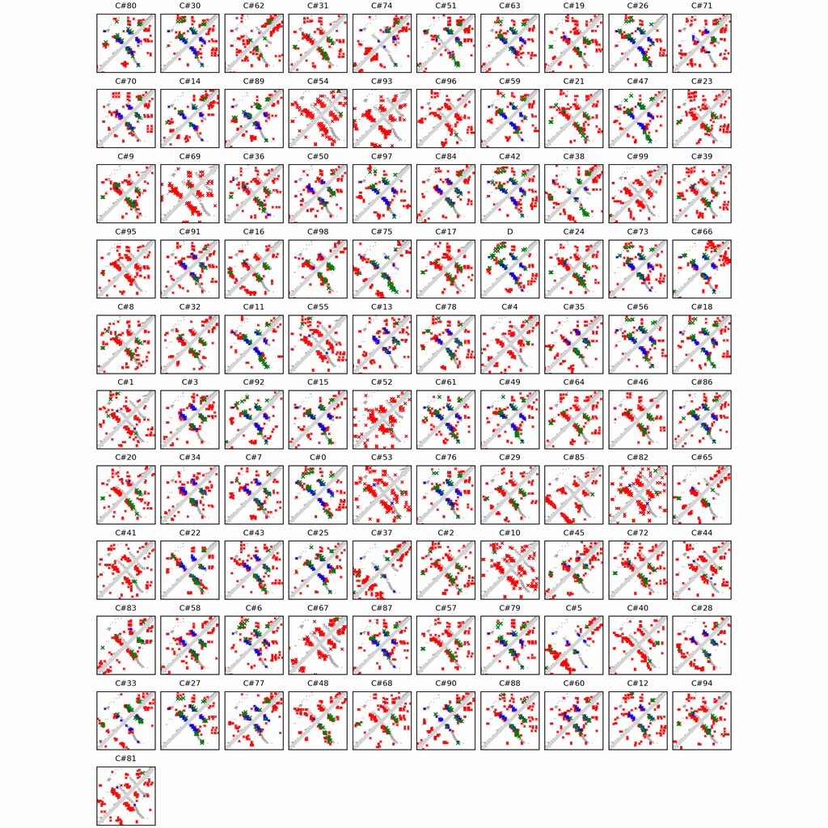

## Figure 8: Phylo null: tree with shuffled cluster fold labels.

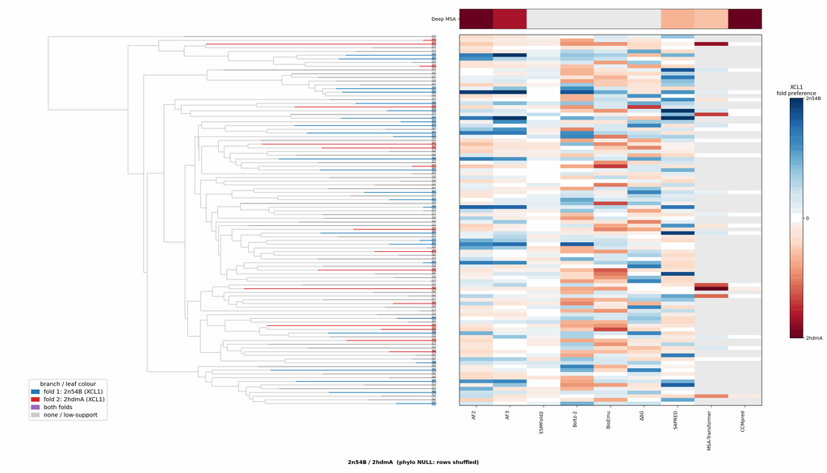

## Cluster metrics table

Per-cluster metrics underlying the figures above.

| cluster | n | neff | AF2_TM1 | AF2_TM2 | AF3_TM1 | AF3_TM2 | RE-MSAT-COM | RE-MSAT1 | RE-MSAT2 | ESM_SEQIDS | ESM_TM1 | ESM_TM2 | ΔΔG_Bias | ΔΔG_Bias_std | ΔΔG_frac_F1 | Boltz2_pref | S4PRED_pref | CCMpred_pref | BioEmu_pref |
| --- | --- | --- | --- | --- | --- | --- | --- | --- | --- | --- | --- | --- | --- | --- | --- | --- | --- | --- | --- |
| Deep | - | - | 0.34 | 0.77 | 0.34 | 0.78 | 0.4 | 0.25 | 0.5 | - | - | - | - | - | - | - | -0.1 | -0.15 | - |
| 000 | 503.0 | 311.0 | 0.32 | 0.62 | 0.33 | 0.67 | 0.41 | 0.27 | 0.51 | 001; 008; 009; 008; 005; 003; 009; 001; 005; 003 | 0.33 ± 0.00 | 0.68 ± 0.07 | 1.74 | 2.12 | 0.7 | -0.32 | -0.12 | -0.01 | -0.17 |
| 001 | 276.0 | 149.0 | 0.31 | 0.68 | 0.32 | 0.69 | 0.02 | 0.01 | 0.05 | 001; 002; 002; 001; 005; 006; 007; 008; 010; 005 | 0.32 ± 0.00 | 0.67 ± 0.02 | 0.74 | 2.23 | 0.6 | -0.36 | -0.14 | 0.0 | -0.21 |
| 002 | 194.0 | 90.0 | 0.26 | 0.37 | 0.28 | 0.28 | 0.0 | 0.06 | 0.05 | 009; 004; 004; 009; 002; 002; 001; 008; 007; 001 | 0.33 ± 0.01 | 0.62 ± 0.10 | 0.82 | 2.98 | 0.6 | -0.33 | -0.08 | 0.0 | -0.04 |
| 003 | 167.0 | 81.0 | 0.21 | 0.32 | 0.19 | 0.33 | 0.28 | 0.2 | 0.15 | 002; 005; 005; 002; 008; 008; 001; 007; 006; 003 | 0.32 ± 0.02 | 0.65 ± 0.03 | 0.68 | 2.72 | 0.5 | -0.11 | -0.18 | 0.0 | -0.02 |
| 004 | 161.0 | 93.0 | 0.33 | 0.69 | 0.33 | 0.69 | 0.0 | 0.0 | 0.0 | 010; 010; 002; 002; 008; 006; 005; 001; 008; 006 | 0.33 ± 0.00 | 0.65 ± 0.05 | 0.89 | 1.2 | 0.7 | -0.14 | 0.03 | 0.0 | -0.17 |
| 005 | 129.0 | 23.0 | 0.51 | 0.36 | 0.5 | 0.29 | 0.06 | 0.02 | 0.02 | 004; 004; 007; 007; 003; 009; 006; 009; 006; 002 | 0.32 ± 0.00 | 0.67 ± 0.05 | 0.93 | 3.01 | 0.4 | 0.19 | 0.04 | 0.0 | 0.07 |
| 006 | 120.0 | 75.0 | 0.33 | 0.66 | 0.33 | 0.66 | 0.27 | 0.12 | 0.27 | 001; 006; 006; 005; 003; 001; 005; 003; 007; 009 | 0.33 ± 0.00 | 0.70 ± 0.03 | 5.1 | 2.88 | 0.9 | -0.12 | -0.07 | 0.0 | -0.1 |
| 007 | 117.0 | 74.0 | 0.33 | 0.57 | 0.34 | 0.53 | 0.18 | 0.21 | 0.1 | 002; 002; 010; 003; 003; 004; 009; 008; 004; 008 | 0.32 ± 0.01 | 0.69 ± 0.03 | 1.45 | 2.76 | 0.6 | -0.2 | 0.13 | 0.0 | -0.09 |
| 008 | 112.0 | 68.0 | 0.24 | 0.44 | 0.32 | 0.67 | 0.0 | 0.07 | 0.04 | 008; 008; 010; 010; 009; 006; 002; 002; 001; 009 | 0.32 ± 0.01 | 0.67 ± 0.05 | 0.01 | 1.47 | 0.4 | -0.3 | -0.18 | 0.0 | -0.05 |
| 009 | 110.0 | 53.0 | 0.31 | 0.44 | 0.34 | 0.62 | 0.04 | 0.07 | 0.04 | 001; 009; 009; 008; 004; 002; 002; 001; 008; 004 | 0.33 ± 0.00 | 0.66 ± 0.03 | 2.79 | 2.88 | 0.8 | -0.08 | 0.01 | 0.0 | -0.04 |
| 010 | 107.0 | 71.0 | 0.24 | 0.47 | 0.25 | 0.4 | 0.0 | 0.0 | 0.0 | 009; 009; 003; 008; 008; 003; 001; 002; 007; 005 | 0.33 ± 0.01 | 0.65 ± 0.05 | 1.68 | 2.47 | 0.7 | -0.08 | -0.16 | 0.0 | -0.09 |
| 011 | 107.0 | 69.0 | 0.35 | 0.59 | 0.34 | 0.6 | 0.44 | 0.26 | 0.39 | 009; 009; 005; 006; 006; 005; 001; 002; 008; 007 | 0.33 ± 0.01 | 0.68 ± 0.05 | 1.71 | 2.12 | 0.7 | -0.2 | -0.01 | 0.0 | -0.1 |
| 012 | 106.0 | 66.0 | 0.34 | 0.62 | 0.32 | 0.62 | 0.24 | 0.15 | 0.17 | 001; 001; 002; 004; 006; 007; 006; 005; 004; 002 | 0.32 ± 0.00 | 0.66 ± 0.03 | 1.17 | 2.45 | 0.6 | -0.28 | 0.04 | 0.0 | -0.01 |
| 013 | 101.0 | 29.0 | 0.32 | 0.65 | 0.32 | 0.67 | 0.1 | 0.06 | 0.05 | 010; 010; 006; 006; 001; 001; 002; 002; 003; 003 | 0.33 ± 0.01 | 0.67 ± 0.06 | -0.28 | 1.73 | 0.3 | -0.34 | -0.09 | 0.0 | -0.08 |
| 014 | 96.0 | 44.0 | 0.25 | 0.42 | 0.31 | 0.7 | 0.1 | 0.04 | 0.1 | 010; 006; 005; 006; 002; 002; 010; 005; 001; 004 | 0.34 ± 0.00 | 0.65 ± 0.05 | 0.82 | 2.46 | 0.5 | -0.2 | -0.18 | -0.01 | -0.05 |
| 015 | 96.0 | 65.0 | 0.31 | 0.58 | 0.33 | 0.61 | 0.41 | 0.2 | 0.32 | 009; 009; 003; 003; 001; 002; 008; 007; 005; 004 | 0.33 ± 0.01 | 0.64 ± 0.06 | 2.01 | 2.94 | 0.7 | -0.28 | 0.11 | 0.0 | -0.1 |
| 016 | 96.0 | 63.0 | 0.35 | 0.51 | 0.31 | 0.54 | 0.0 | 0.06 | 0.0 | 002; 002; 004; 003; 004; 009; 007; 007; 009; 003 | 0.33 ± 0.00 | 0.65 ± 0.03 | 2.26 | 1.32 | 0.9 | -0.26 | 0.14 | 0.0 | -0.16 |
| 017 | 95.0 | 54.0 | 0.32 | 0.62 | 0.3 | 0.63 | 0.0 | 0.08 | 0.04 | 010; 008; 008; 010; 006; 006; 002; 009; 007; 004 | 0.33 ± 0.01 | 0.66 ± 0.07 | 1.04 | 2.34 | 0.6 | -0.3 | -0.18 | 0.0 | -0.07 |
| 018 | 94.0 | 45.0 | 0.32 | 0.63 | 0.34 | 0.43 | 0.35 | 0.18 | 0.25 | 008; 008; 002; 002; 001; 005; 001; 005; 009; 009 | 0.33 ± 0.01 | 0.66 ± 0.02 | 2.5 | 2.93 | 0.8 | -0.03 | -0.16 | 0.0 | -0.07 |
| 019 | 93.0 | 57.0 | 0.32 | 0.49 | 0.33 | 0.64 | 0.0 | 0.04 | 0.0 | 008; 008; 001; 004; 003; 001; 004; 003; 006; 002 | 0.33 ± 0.01 | 0.65 ± 0.04 | 5.03 | 2.04 | 1.0 | -0.19 | -0.18 | 0.0 | -0.02 |
| 020 | 92.0 | 56.0 | 0.32 | 0.63 | 0.31 | 0.63 | 0.0 | 0.1 | 0.0 | 010; 010; 006; 006; 005; 004; 002; 001; 005; 004 | 0.33 ± 0.01 | 0.66 ± 0.07 | 0.19 | 1.9 | 0.7 | -0.16 | -0.17 | 0.0 | -0.12 |
| 021 | 92.0 | 60.0 | 0.32 | 0.7 | 0.31 | 0.68 | 0.0 | 0.11 | 0.04 | - | - | - | 0.8 | 3.03 | 0.6 | -0.02 | -0.14 | - | -0.2 |
| 022 | 90.0 | 56.0 | 0.33 | 0.59 | 0.33 | 0.59 | 0.37 | 0.32 | 0.24 | - | - | - | 2.46 | 2.25 | 1.0 | -0.01 | -0.09 | - | -0.04 |
| 023 | 90.0 | 53.0 | 0.24 | 0.4 | 0.31 | 0.66 | 0.0 | 0.05 | 0.0 | - | - | - | -0.43 | 2.09 | 0.4 | -0.02 | -0.12 | - | -0.04 |
| 024 | 89.0 | 45.0 | 0.32 | 0.63 | 0.25 | 0.34 | 0.0 | 0.08 | 0.0 | - | - | - | 0.96 | 2.97 | 0.4 | -0.31 | 0.1 | - | -0.16 |
| 025 | 88.0 | 54.0 | 0.32 | 0.68 | 0.27 | 0.64 | 0.4 | 0.2 | 0.3 | - | - | - | 1.85 | 3.96 | 0.7 | -0.24 | -0.02 | - | -0.04 |
| 026 | 88.0 | 58.0 | 0.34 | 0.66 | 0.32 | 0.67 | 0.38 | 0.27 | 0.42 | - | - | - | 0.87 | 2.32 | 0.8 | -0.34 | -0.14 | - | -0.04 |
| 027 | 87.0 | 59.0 | 0.33 | 0.64 | 0.32 | 0.64 | 0.49 | 0.28 | 0.47 | - | - | - | 2.27 | 2.62 | 0.8 | -0.34 | -0.06 | - | -0.21 |
| 028 | 87.0 | 41.0 | 0.31 | 0.55 | 0.28 | 0.51 | 0.33 | 0.18 | 0.17 | - | - | - | 0.63 | 1.76 | 0.6 | -0.35 | -0.02 | - | -0.15 |

[output cut: 71 more lines]